# Quality comparison of customer reviews of different smartphones on online marketplaces

Nadine Obeid, Clarence Koehle, Lucas Vogt and Arturo García Luna Beltrán

18 December, 2022

# Clustering of documents

In this section, we are using our previously created embedded document matrix in order to cluster documents together. In theory, the clustering should generate groups of similar documents. This is useful to understand the main topics and themes discussed by customers in their reviews.

For the clustering approach, we decided to create a total of 7 groups with `nstart=20`. The graph below includes a subset of 500 reviews showing the results.

```r
# # Read all reviews
all_reviews <- read.csv(here::here("data/smartphone_reviews_final.csv"))

# # Read embedded document matrix
embedded_documents <- select(read.csv(here::here("script/unsupervised_learning/embedding/embedding_data/embedded_documents.csv")), -X)

# # Clustering of documents
set.seed(650)
number_of_centers <- 7
all_reviews_clustering <- kmeans(embedded_documents, centers = number_of_centers, nstart = 20)

# Store size of clusters
cluster_size <- tibble(cluster = seq(1:number_of_centers),
                       number_of_reviews = all_reviews_clustering$size)
```

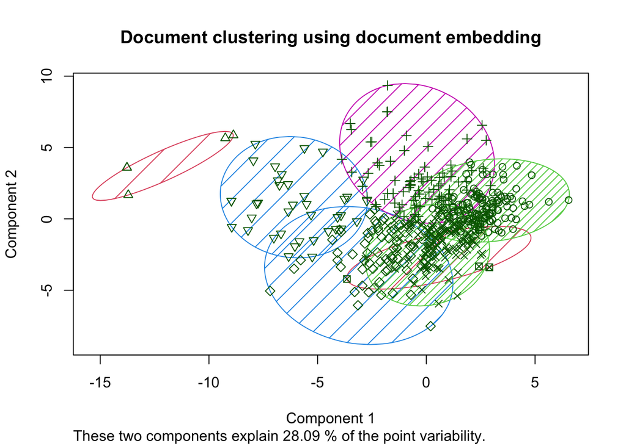

In order to capture the topics discussed in each cluster, we decided to:

- Tokenize the reviews (remove punctuation, lowercasing and removing numbers)
- Remove stop words
- Group by cluster and count word occurrence and frequency
- Keep words with occurrences higher than 3
- Keep the top 15 (max) per cluster
- Graph the results

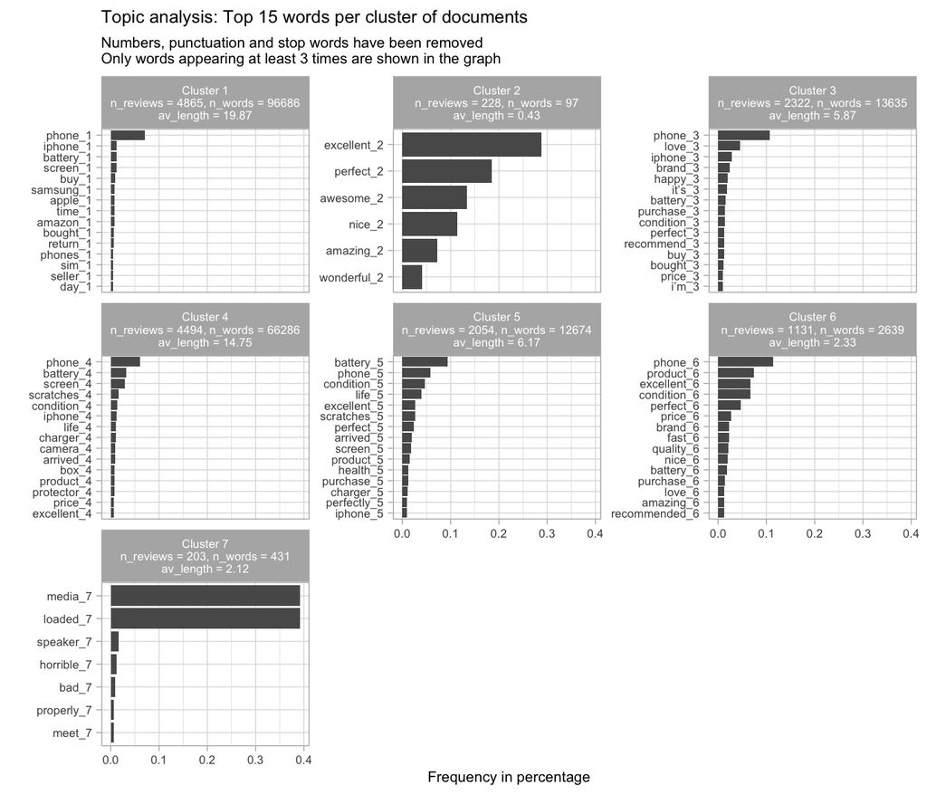

```r
# Create dataset for plotting: Get top words per cluster
cluster_topics <- all_reviews %>%
  mutate(review_id = seq(1:nrow(all_reviews))) %>%
  relocate(review_id, .before = "Brand") %>%
  unnest_tokens(output = "word",
                input = "Reviews",
                to_lower = TRUE,
                strip_punct = TRUE,
                strip_numeric = TRUE) %>%
  filter(word %notin% stop_words$word) %>%
  group_by(cluster, word) %>%
  tally() %>%
  mutate(freq = n/sum(n)) %>%
  filter(n >= 3) %>%
  arrange(cluster, desc(freq)) %>%
  top_n(15, freq) %>%
  left_join(cluster_size, by = c("cluster" = "cluster")) %>%
  mutate(cluster_header = paste0("Cluster ", cluster, "\nn_reviews = ", number_of_reviews, ", n_words = ", round(n/freq), "\nav_length = ", round(round(n/freq)/number_of_reviews, 2)))
```

Thanks to the results of the clustering approach, we are able to observe several patterns in the reviews.

1. Cluster size is not uniformly distributed
2. The average length of reviews varies from a cluster to another (min = 0.43, max = 19.87)
3. Cluster 1 seems to group longer reviews and general comments about the battery, screen, place of purchase and return conditions. This cluster might include all the reviews where customers describe their overall experience in order to inform future purchasers.
4. Cluster 4 is similar to cluster 1 but is slightly more oriented towards the phones’ conditions after a certain usage period (scratch, condition, charger, protector).
5. Cluster 5 has slightly shorter reviews and seems to have a focus on battery and battery life. Further investigation would be needed but it could be that the overall sentiment of that group of reviews is positive since it also includes several occurences of words such as `excellent`, `perfect` and `perfectly`.
6. Cluster 3 seems to group reviews of happy customers that are willing to share on their experiences (‘promoters’).
7. Cluster 2 and 6 appears to contain comments of happy customers that wanted to express their satisfaction in a very concise manner (short reviews).
8. Finally, cluster 7 seems to be grouping bad comments about speakers’ quality.

As we can see, it seems that the clustering managed to surface groups of positive comments. However, it is quite surprising to see that the only cluster of negative comments contains only 203 reviews and mostly talks about the quality of the media play and speakers. It would be worth analyzing large clusters that do not seem to surface particular sign of satisfaction to better understand their content (1, 4, 5). Some approaches include increasing the number of clusters or ‘cluster the clusters of interest’.